# Statistical learning: Advanced - M2 TIDE

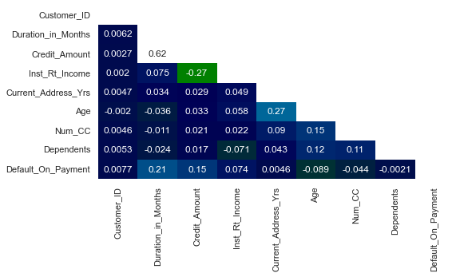

```python
# CORRELATION MATRIX
plt.figure(figsize=(8,4))
sns.heatmap(data.corr(),annot=True,cmap="ocean",cbar=False,mask=np.triu(np.ones_like(data.corr(), dtype = bool)))
plt.show()
```

```python
corr_matrix = data.corr()
upper_tri = corr_matrix.where(np.triu(np.ones(corr_matrix.shape),k=1).astype(np.bool))
def top_correlation(df,n):
     correlation = upper_tri.stack().sort_values(ascending=False)
     correlation = pd.DataFrame(correlation).reset_index()
     correlation.columns=["Variable 1","Variable 2","Correlation"]
     correlation = correlation.reindex(correlation.Correlation.abs().sort_values(ascending=False).index)
     return correlation.head(n)
top_correlation(data,10)
```

|  | Variable 1 | Variable 2 | Correlation |
| --- | --- | --- | --- |
| 0 | Duration_in_Months | Credit_Amount | 0.624984 |
| 35 | Credit_Amount | Inst_Rt_Income | -0.271316 |
| 1 | Current_Address_Yrs | Age | 0.266419 |
| 2 | Duration_in_Months | Default_On_Payment | 0.210222 |
| 3 | Credit_Amount | Default_On_Payment | 0.152812 |
| 4 | Age | Num_CC | 0.149254 |
| 5 | Age | Dependents | 0.118201 |
| 6 | Num_CC | Dependents | 0.109667 |
| 7 | Current_Address_Yrs | Num_CC | 0.089625 |
| 34 | Age | Default_On_Payment | -0.088612 |

**Let's plot the distribution for each numerical feature**

```python
ndefault = data[data['Default_On_Payment'] == 0]
default = data[data['Default_On_Payment'] == 1]
```

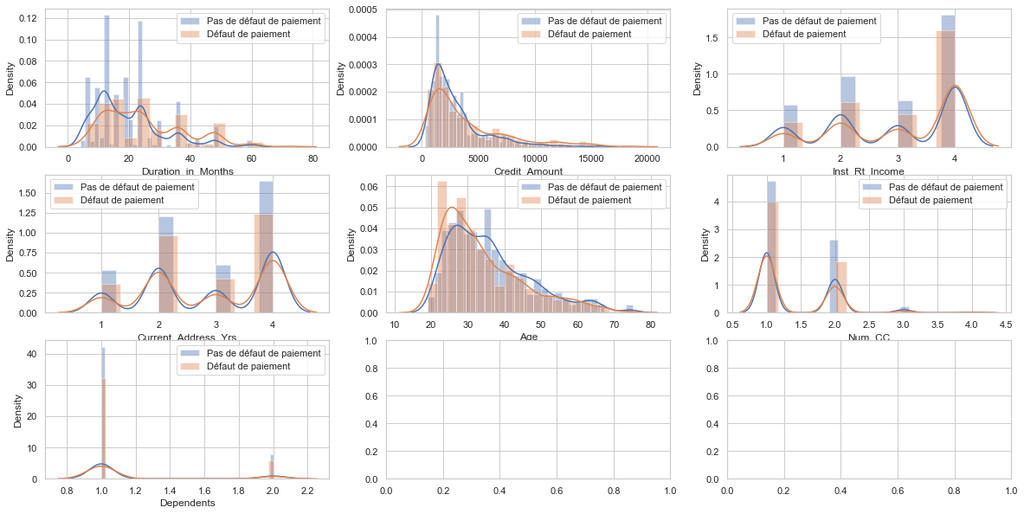

```python
# Numerical features analysis

var_continues = ['Duration_in_Months', 'Credit_Amount', 'Inst_Rt_Income', 'Current_Address_Yrs', 'Age', 'Num_CC', 'Dependents']

plt.figure()

fig, axes = plt.subplots(3, 3, figsize=(20, 10))

sns.distplot(ndefault['Duration_in_Months'], label = "Pas de défaut de paiement", ax = axes[0,0])
sns.distplot(default['Duration_in_Months'], label = "Défaut de paiement", ax = axes[0,0]).legend()

sns.distplot(ndefault['Credit_Amount'], label = "Pas de défaut de paiement", ax = axes[0,1])
sns.distplot(default['Credit_Amount'], label = "Défaut de paiement", ax = axes[0,1]).legend()

sns.distplot(ndefault['Inst_Rt_Income'], label = "Pas de défaut de paiement", ax = axes[0,2])
sns.distplot(default['Inst_Rt_Income'], label = "Défaut de paiement", ax = axes[0,2]).legend()

sns.distplot(ndefault['Current_Address_Yrs'], label = "Pas de défaut de paiement", ax = axes[1,0])
sns.distplot(default['Current_Address_Yrs'], label = "Défaut de paiement", ax = axes[1,0]).legend()

sns.distplot(ndefault['Age'], label = "Pas de défaut de paiement", ax = axes[1,1])
sns.distplot(default['Age'], label = "Défaut de paiement", ax = axes[1,1]).legend()

sns.distplot(ndefault['Num_CC'], label = "Pas de défaut de paiement", ax = axes[1,2])
sns.distplot(default['Num_CC'], label = "Défaut de paiement", ax = axes[1,2]).legend()

sns.distplot(ndefault['Dependents'], label = "Pas de défaut de paiement", ax = axes[2,0])
sns.distplot(default['Dependents'], label = "Défaut de paiement", ax = axes[2,0]).legend()

plt.show();
```

Similar distributions are observed for all numerical variables, whether or not a default occurs. However, there is a small difference in the distributions for the variables 'Duration in Months' and 'Age'.

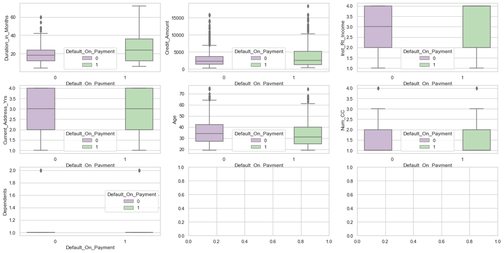

```python
plt.figure()

fig, axes = plt.subplots(3, 3, figsize=(20, 10))

sns.boxplot(ax = axes[0,0], x="Default_On_Payment", y="Duration_in_Months", hue="Default_On_Payment",data=data, palette="PRGn",showfliers=True) #Show the outliers

sns.boxplot(ax = axes[0,1], x="Default_On_Payment", y="Credit_Amount", hue="Default_On_Payment",data=data, palette="PRGn",showfliers=True) #Show the outliers

sns.boxplot(ax = axes[0,2], x="Default_On_Payment", y="Inst_Rt_Income", hue="Default_On_Payment",data=data, palette="PRGn",showfliers=True) #Show the outliers

sns.boxplot(ax = axes[1,0], x="Default_On_Payment", y="Current_Address_Yrs", hue="Default_On_Payment",data=data, palette="PRGn",showfliers=True) #Show the outliers

sns.boxplot(ax = axes[1,1], x="Default_On_Payment", y="Age", hue="Default_On_Payment",data=data, palette="PRGn",showfliers=True) #Show the outliers

sns.boxplot(ax = axes[1,2], x="Default_On_Payment", y="Num_CC", hue="Default_On_Payment",data=data, palette="PRGn",showfliers=True) #Show the outliers

sns.boxplot(ax = axes[2,0], x="Default_On_Payment", y="Dependents", hue="Default_On_Payment",data=data, palette="PRGn",showfliers=True) #Show the outliers

plt.show();
```

Here again, we notice that the difference between the boxplots is most visible for the variable Duration in Mounth. We observe a large presence of outliers for the variables Credit_Amount and Dependents

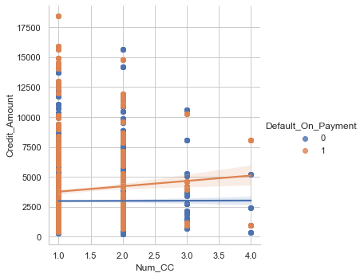

```python
# Num_CC and Credit Amount
sns.lmplot(x = 'Num_CC', y = 'Credit_Amount', hue='Default_On_Payment', data = data);
```

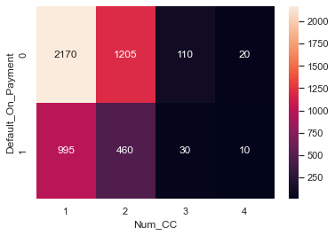

```python
sns.heatmap(pd.crosstab(data['Default_On_Payment'], data['Num_CC']), annot=True, fmt='d');
```

```python
data.groupby(['Default_On_Payment']).agg({'Duration_in_Months':'mean', 'Credit_Amount': 'mean', 'Inst_Rt_Income' : 'mean',
                                          'Current_Address_Yrs' : 'mean', 'Age':'mean', 'Num_CC' :'mean', 'Dependents' : 'mean'})
```

| Default_On_Payment | Duration_in_Months | Credit_Amount | Inst_Rt_Income | Current_Address_Yrs | Age | Num_CC | Dependents |
| --- | --- | --- | --- | --- | --- | --- | --- |
| 0 | 19.248217 | 2989.687589 | 2.918688 | 2.841655 | 36.203994 | 1.423680 | 1.155492 |
| 1 | 24.782609 | 3931.394649 | 3.100334 | 2.852843 | 34.003344 | 1.367893 | 1.153846 |

In terms of mean, the largest differences between default and non-default payments are observed for the Duration_in_Months and Credit_Amount variables. We can assume that these are the most influential numerical variables in detecting a default payment.

```python
# Duration in Months feature analysis
data['Duration_in_Months'].value_counts()
```

```
24    920
12    895
18    565
36    415
6     375
15    320
9     245
48    240
30    200
21    150
10    140
60     65
27     65
42     55
11     45
```

[output cut: 19 more lines]

```python
def duration_scaled(x):
    if x['Duration_in_Months']>0 and x['Duration_in_Months'] < 10:
        return 0
    elif x['Duration_in_Months']>=10 and x['Duration_in_Months'] < 20:
        return 10
    elif x['Duration_in_Months']>=20 and x['Duration_in_Months'] < 30:
        return 20
    elif x['Duration_in_Months']>=30 and x['Duration_in_Months'] < 40:
        return 30
    elif x['Duration_in_Months']>=40 and x['Duration_in_Months'] < 50:
        return 40
    elif x['Duration_in_Months']>=50 and x['Duration_in_Months'] < 60:
        return 50
    elif x['Duration_in_Months']>=60 and x['Duration_in_Months'] < 70:
        return 60
    else :
        return 70

data['Duration_in_Months_scaled'] = data.apply(duration_scaled, axis = 1)
```

```python
table = data.groupby(['Duration_in_Months_scaled', 'Default_On_Payment'])['Credit_Amount'].aggregate(['count', 'min', 'max', 'sum', 'mean', 'median', 'var']).reset_index()
table = pd.DataFrame(table)
table.columns = ['Duration in Months Scaled', 'Default On Payment', 'Transactions', 'Min', 'Max', 'Sum', 'Mean', 'Median', 'Var']
table
```

|  | Duration in Months Scaled | Default On Payment | Transactions | Min | Max | Sum | Mean | Median | Var |
| --- | --- | --- | --- | --- | --- | --- | --- | --- | --- |
| 0 | 0 | 0 | 595 | 250 | 6761 | 926995 | 1557.974790 | 1343.0 | 1.007190e+06 |
| 1 | 0 | 1 | 120 | 433 | 14896 | 323170 | 2693.083333 | 1351.5 | 1.459237e+07 |
| 2 | 10 | 0 | 1475 | 339 | 8471 | 3171365 | 2150.077966 | 1797.0 | 1.884445e+06 |
| 3 | 10 | 1 | 540 | 433 | 12976 | 1200805 | 2223.712963 | 1498.0 | 4.089570e+06 |
| 4 | 20 | 0 | 845 | 571 | 9277 | 2807950 | 3323.017751 | 2872.0 | 3.373503e+06 |
| 5 | 20 | 1 | 360 | 915 | 12680 | 1244230 | 3456.194444 | 2529.0 | 8.097003e+06 |
| 6 | 30 | 0 | 395 | 909 | 15857 | 2092910 | 5298.506329 | 4454.0 | 8.988722e+06 |
| 7 | 30 | 1 | 260 | 1819 | 14318 | 1473100 | 5665.769231 | 4459.0 | 1.123720e+07 |
| 8 | 40 | 0 | 155 | 2751 | 12749 | 1067350 | 6886.129032 | 6681.0 | 7.500084e+06 |
| 9 | 40 | 1 | 175 | 1845 | 18424 | 1245240 | 7115.657143 | 6331.0 | 1.433810e+07 |
| 10 | 50 | 0 | 5 | 9436 | 9436 | 47180 | 9436.000000 | 9436.0 | 0.000000e+00 |
| 11 | 50 | 1 | 5 | 15945 | 15945 | 79725 | 15945.000000 | 15945.0 | 0.000000e+00 |
| 12 | 60 | 0 | 35 | 6527 | 15653 | 365105 | 10431.571429 | 10144.0 | 9.463818e+06 |
| 13 | 60 | 1 | 30 | 6288 | 14782 | 283190 | 9439.666667 | 7352.5 | 1.293361e+07 |
| 14 | 70 | 1 | 5 | 5595 | 5595 | 27975 | 5595.000000 | 5595.0 | 0.000000e+00 |

In order to compare properly, we want to have the same number of observations in each group. We then modify the creation of the table

```python
gb = data.groupby(['Duration_in_Months_scaled', 'Default_On_Payment'])['Default_On_Payment'].count()
gb
```

```
Duration_in_Months_scaled  Default_On_Payment
0                          0                      595
                           1                      120
10                         0                     1475
                           1                      540
20                         0                      845
                           1                      360
30                         0                      395
                           1                      260
40                         0                      155
                           1                      175
50                         0                        5
                           1                        5
60                         0                       35
                           1                       30
70                         1                        5
Name: Default_On_Payment, dtype: int64
```

```python
df0d = data[(data['Duration_in_Months_scaled'] == 0) & (data['Default_On_Payment'] == 1)]
df0nd = data[(data['Duration_in_Months_scaled'] == 0) & (data['Default_On_Payment'] == 0)].sample(n=gb[0][1])

df10d = data[(data['Duration_in_Months_scaled'] == 10) & (data['Default_On_Payment'] == 1)]
df10nd = data[(data['Duration_in_Months_scaled'] == 10) & (data['Default_On_Payment'] == 0)].sample(n=gb[10][1])

df20d = data[(data['Duration_in_Months_scaled'] == 20) & (data['Default_On_Payment'] == 1)]
df20nd = data[(data['Duration_in_Months_scaled'] == 20) & (data['Default_On_Payment'] == 0)].sample(n=gb[20][1])

df30d = data[(data['Duration_in_Months_scaled'] == 30) & (data['Default_On_Payment'] == 1)]
df30nd = data[(data['Duration_in_Months_scaled'] == 30) & (data['Default_On_Payment'] == 0)].sample(n=gb[30][1])

df40d = data[(data['Duration_in_Months_scaled'] == 40) & (data['Default_On_Payment'] == 1)].sample(n=gb[40][0])
df40nd = data[(data['Duration_in_Months_scaled'] == 40) & (data['Default_On_Payment'] == 0)]

df50d = data[(data['Duration_in_Months_scaled'] == 50) & (data['Default_On_Payment'] == 1)]
df50nd = data[(data['Duration_in_Months_scaled'] == 50) & (data['Default_On_Payment'] == 0)].sample(n=gb[50][1])

df60d = data[(data['Duration_in_Months_scaled'] == 60) & (data['Default_On_Payment'] == 1)]
df60nd = data[(data['Duration_in_Months_scaled'] == 60) & (data['Default_On_Payment'] == 0)].sample(n=gb[60][1])


df = pd.concat([df0d, df0nd, df20d, df20nd, df30d, df30nd, df40d, df40nd, df50d, df50nd, df60d, df60nd], axis = 0)
```

```python
table = df.groupby(['Duration_in_Months_scaled', 'Default_On_Payment'])['Credit_Amount'].aggregate(['count', 'min', 'max', 'sum', 'mean', 'median', 'var']).reset_index()
table = pd.DataFrame(table)
table.columns = ['Duration in Months Scaled', 'Default On Payment', 'Transactions', 'Min', 'Max', 'Sum', 'Mean', 'Median', 'Var']
table
```

|  | Duration in Months Scaled | Default On Payment | Transactions | Min | Max | Sum | Mean | Median | Var |
| --- | --- | --- | --- | --- | --- | --- | --- | --- | --- |
| 0 | 0 | 0 | 120 | 250 | 6761 | 178738 | 1489.483333 | 1266.0 | 1.027564e+06 |
| 1 | 0 | 1 | 120 | 433 | 14896 | 323170 | 2693.083333 | 1351.5 | 1.459237e+07 |
| 2 | 20 | 0 | 360 | 571 | 9277 | 1187368 | 3298.244444 | 2797.0 | 3.658565e+06 |
| 3 | 20 | 1 | 360 | 915 | 12680 | 1244230 | 3456.194444 | 2529.0 | 8.097003e+06 |
| 4 | 30 | 0 | 260 | 909 | 15857 | 1392649 | 5356.342308 | 4473.0 | 8.906610e+06 |
| 5 | 30 | 1 | 260 | 1819 | 14318 | 1473100 | 5665.769231 | 4459.0 | 1.123720e+07 |
| 6 | 40 | 0 | 155 | 2751 | 12749 | 1067350 | 6886.129032 | 6681.0 | 7.500084e+06 |
| 7 | 40 | 1 | 155 | 1845 | 18424 | 1108416 | 7151.070968 | 6331.0 | 1.448117e+07 |
| 8 | 50 | 0 | 5 | 9436 | 9436 | 47180 | 9436.000000 | 9436.0 | 0.000000e+00 |
| 9 | 50 | 1 | 5 | 15945 | 15945 | 79725 | 15945.000000 | 15945.0 | 0.000000e+00 |
| 10 | 60 | 0 | 30 | 6527 | 15653 | 318103 | 10603.433333 | 10144.0 | 9.786116e+06 |
| 11 | 60 | 1 | 30 | 6288 | 14782 | 283190 | 9439.666667 | 7352.5 | 1.293361e+07 |

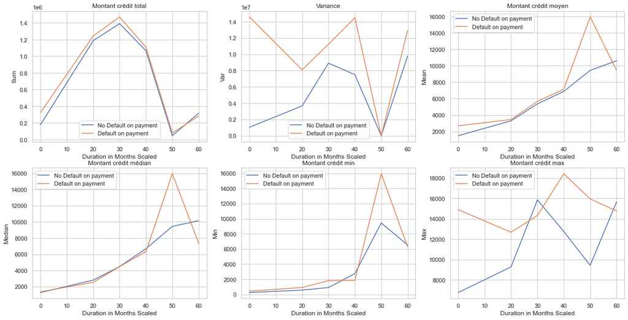

```python
plt.figure()

fig, axes = plt.subplots(2, 3, figsize=(20, 10))

sns.lineplot(x="Duration in Months Scaled", y="Sum", data=table.loc[table['Default On Payment']==0], label = "No Default on payment", ax = axes[0,0])
sns.lineplot(x="Duration in Months Scaled", y="Sum", data=table.loc[table['Default On Payment']==1], label = "Default on payment", ax = axes[0,0])
axes[0,0].title.set_text('Montant crédit total')

sns.lineplot(x="Duration in Months Scaled", y="Var", data=table.loc[table['Default On Payment']==0], label = "No Default on payment", ax = axes[0,1])
sns.lineplot(x="Duration in Months Scaled", y="Var", data=table.loc[table['Default On Payment']==1], label = "Default on payment", ax = axes[0,1])
axes[0,1].title.set_text('Variance')

sns.lineplot(x="Duration in Months Scaled", y="Mean", data=table.loc[table['Default On Payment']==0], label = "No Default on payment", ax = axes[0,2])
sns.lineplot(x="Duration in Months Scaled", y="Mean", data=table.loc[table['Default On Payment']==1], label = "Default on payment", ax = axes[0,2])
axes[0,2].title.set_text('Montant crédit moyen')

sns.lineplot(x="Duration in Months Scaled", y="Median", data=table.loc[table['Default On Payment']==0], label = "No Default on payment", ax = axes[1,0])
sns.lineplot(x="Duration in Months Scaled", y="Median", data=table.loc[table['Default On Payment']==1], label = "Default on payment", ax = axes[1,0])
axes[1,0].title.set_text('Montant crédit médian')

sns.lineplot(x="Duration in Months Scaled", y="Min", data=table.loc[table['Default On Payment']==0], label = "No Default on payment", ax = axes[1,1])
sns.lineplot(x="Duration in Months Scaled", y="Min", data=table.loc[table['Default On Payment']==1], label = "Default on payment", ax = axes[1,1])
axes[1,1].title.set_text('Montant crédit min')

sns.lineplot(x="Duration in Months Scaled", y="Max", data=table.loc[table['Default On Payment']==0], label = "No Default on payment", ax = axes[1,2])
sns.lineplot(x="Duration in Months Scaled", y="Max", data=table.loc[table['Default On Payment']==1], label = "Default on payment", ax = axes[1,2])
axes[1,2].title.set_text('Montant crédit max')


plt.show()
```

```python
data.drop('Duration_in_Months_scaled',axis=1,inplace=True) # Deletion of the variable to avoid autocorrelation
```

**Let's analyse the categorical features**

```python
data.head(2)
```

|  | Customer_ID | Status_Checking_Acc | Duration_in_Months | Credit_History | Purposre_Credit_Taken | Credit_Amount | Savings_Acc | Years_At_Present_Employment | Inst_Rt_Income | Marital_Status_Gender | Other_Debtors_Guarantors | Current_Address_Yrs | Property | Age | Other_Inst_Plans | Housing | Num_CC | Job | Dependents | Telephone | Foreign_Worker | Default_On_Payment |
| --- | --- | --- | --- | --- | --- | --- | --- | --- | --- | --- | --- | --- | --- | --- | --- | --- | --- | --- | --- | --- | --- | --- |
| 0 | 100001 | A11 | 6 | A34 | A43 | 1169 | A65 | A75 | 4 | A93 | A101 | 4 | A121 | 67 | A143 | A152 | 2 | A173 | 1 | A192 | A201 | 0 |
| 1 | 100002 | A12 | 48 | A32 | A43 | 5951 | A61 | A73 | 2 | A92 | A101 | 2 | A121 | 22 | A143 | A152 | 1 | A173 | 1 | A191 | A201 | 0 |

Let's start by replacing the codes with their values. This will make it easier for us to understand the data

```python
# Variable Status_Checking_ACC
old_values = ['A11','A12','A13','A14']
new_values = ['< 0 USD', 'between 0 and 9.999', '10.000 and more', 'no checking account']
data = data.replace(old_values, new_values)
```

```python
# Variable Credit_History

old_values = ['A30', 'A31', 'A32', 'A33', 'A34']
new_values =  ['no credits taken/all credits paid back duly',
               'all credits at this bank paid back duly',
              'existing credits paid back duly till now',
              'delay in paying off in the past',
              'critical account/other credits existing(not at this bank)']

data = data.replace(old_values, new_values)
```

```python
# Variable Purposre_Credit_Taken
old_values = ['A40', 'A41', 'A42', 'A43', 'A44', 'A45', 'A46', 'A47', 'A48', 'A49', 'A410']
new_values = ['car (new)','car (used)', 'furniture/equipment', 'radio/television', 'domestic appliances',
              'repairs', 'education', '(vacation - does not exist?)', 'retraining', 'business', 'others']

data = data.replace(old_values, new_values)
```

```python
# Variable Savings_Acc
old_values = ['A61', 'A62', 'A63', 'A64', 'A65']
new_values = ['less than 1000', 'between 1000 and 4.999', 'between 5.000 and 9.999', '10.000 and more',
              'unknown/ no savings account' ]

data = data.replace(old_values, new_values)
```

```python
# Variable Years_At_Present_Employment
old_values =  ['A71', 'A72', 'A73', 'A74', 'A75']
new_values = ['unemployed','less than 1 year', 'between 1 and 3 years', 'between 4 and 6 years', '7 years and more']

data = data.replace(old_values, new_values)
```

```python
# Variable Marital_Status_Gender
old_values = ['A91', 'A92', 'A93', 'A94', 'A95']
new_values = ['male : divorced/separated', 'female: divorced/separated/married', 'male : single',
             'male : married/widowed', 'female: single']

data = data.replace(old_values, new_values)
```

```python
# Variable Other_Debtors_Guarantors
old_values = ['A101', 'A102', 'A103']
new_values = ['none', 'co-applicant', 'guarantor']

data = data.replace(old_values, new_values)
```

```python
# Variable Property
old_values = ['A121', 'A122', 'A123', 'A124']
new_values = ['real estate', 'building society savings agreement/life insurance',
             'car or other, not in attribute 6', 'unknown / no property']

data = data.replace(old_values, new_values)
```

```python
# Variable Other_Inst_Plans

old_values = ['A141', 'A142', 'A143']
new_values = ['bank', 'stores', 'none']

data = data.replace(old_values, new_values)
```

```python
# Variable Housing

old_values = ['A151', 'A152', 'A153']
new_values = ['rent', 'own', 'for free']

data = data.replace(old_values, new_values)
```

```python
# Variable Job

old_values = ['A171', 'A172', 'A173', 'A174']
new_values = ['unemployed/ unskilled - non-resident', 'unskilled - resident', 'skilled employee / official',
             'management/ self-employed/highly qualified employee/ officer']

data = data.replace(old_values, new_values)
```

```python
# Variable Telephone

old_values = ['A191', 'A192']
new_values = ['none', 'yes, registered under the customer’s name']

data = data.replace(old_values, new_values)
```

```python
# Variable Foreign_Worker

old_values = ['A201', 'A202']
new_values = ['yes', 'no']

data = data.replace(old_values, new_values)
```

```python
data.head(2)
```

|  | Customer_ID | Status_Checking_Acc | Duration_in_Months | Credit_History | Purposre_Credit_Taken | Credit_Amount | Savings_Acc | Years_At_Present_Employment | Inst_Rt_Income | Marital_Status_Gender | Other_Debtors_Guarantors | Current_Address_Yrs | Property | Age | Other_Inst_Plans | Housing | Num_CC | Job | Dependents | Telephone | Foreign_Worker | Default_On_Payment |
| --- | --- | --- | --- | --- | --- | --- | --- | --- | --- | --- | --- | --- | --- | --- | --- | --- | --- | --- | --- | --- | --- | --- |
| 0 | 100001 | < 0 USD | 6 | critical account/other credits existing(not at... | radio/television | 1169 | unknown/ no savings account | 7 years and more | 4 | male : single | none | 4 | real estate | 67 | none | own | 2 | skilled employee / official | 1 | yes, registered under the customer’s name | yes | 0 |
| 1 | 100002 | between 0 and 9.999 | 48 | existing credits paid back duly till now | radio/television | 5951 | less than 1000 | between 1 and 3 years | 2 | female: divorced/separated/married | none | 2 | real estate | 22 | none | own | 1 | skilled employee / official | 1 | none | yes | 0 |